# Homework 5

Deanna Springgay

4/22/2021

### 8.6

1. The residuals seem to be random around a zero mean.

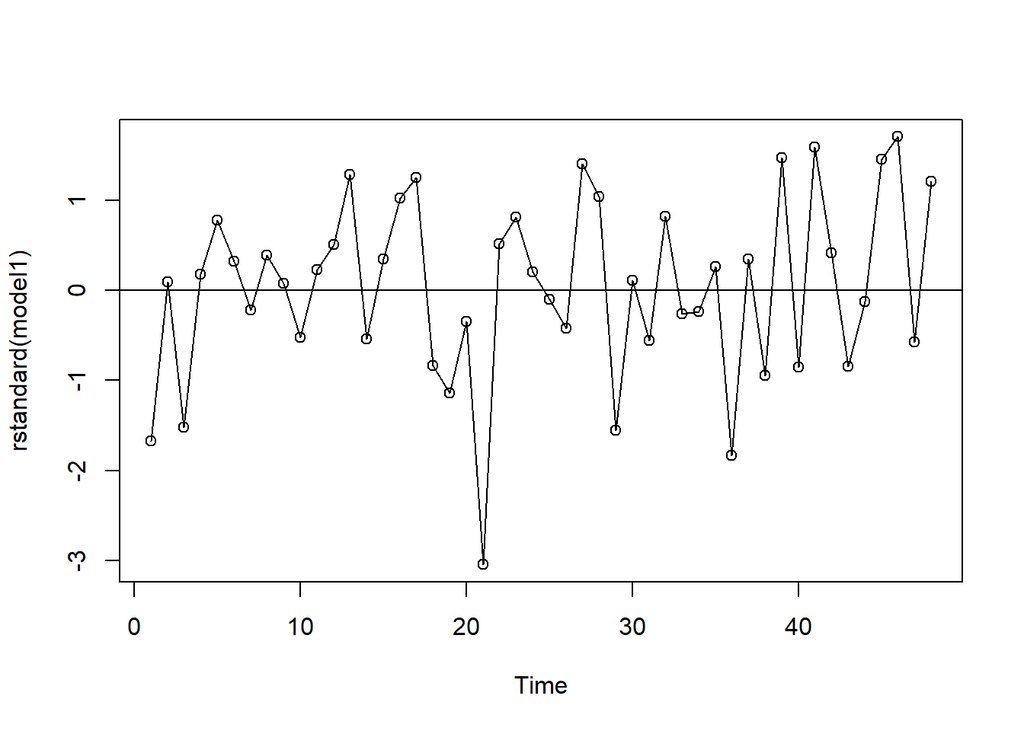

2. The residuals seem to follow a normal distribution.

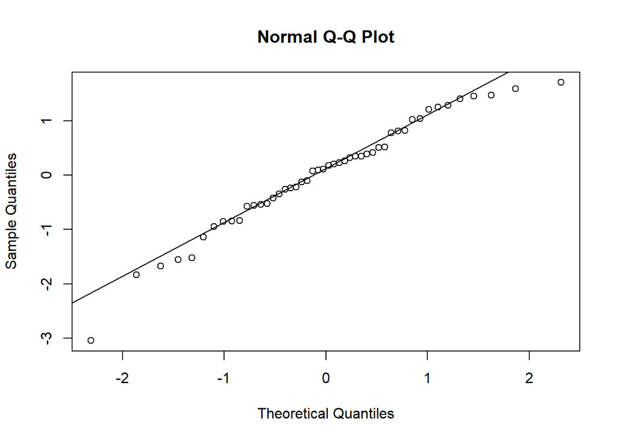

3. None of the lags are significant.

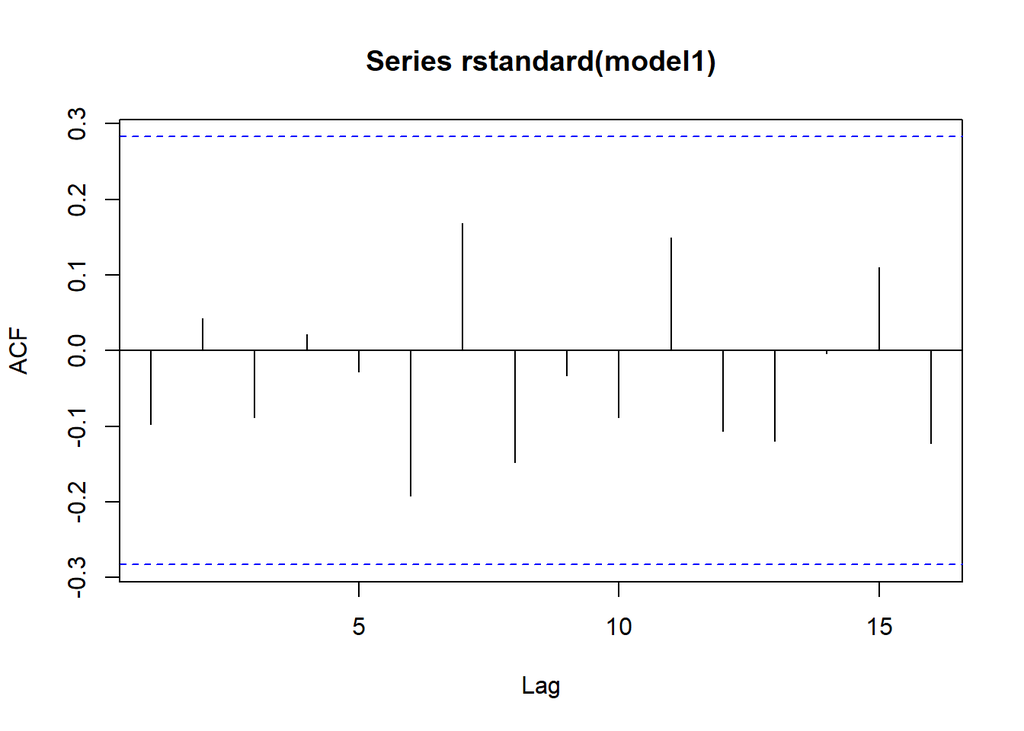

4. From the Ljung-Box test we fail to reject the null hypothesis of independent residuals.

```
##
##  Box-Ljung test
##
## data:  residuals from  model1
## X-squared = 8.9256, df = 10, p-value = 0.5392
```

### 8.9

While both models are significant, the arima(0,1,1) model has a better log likelihood and AIC.

```
##
## Call:
## arima(x = robot, order = c(1, 0, 0))
##
## Coefficients:
##          ar1  intercept
##       0.3074     0.0015
## s.e.  0.0528     0.0002
##
## sigma^2 estimated as 6.482e-06:  log likelihood = 1475.54,  aic = -2947.08
```

```
##
## Call:
## arima(x = robot, order = c(0, 1, 1))
##
## Coefficients:
##           ma1
##       -0.8713
## s.e.   0.0389
##
## sigma^2 estimated as 6.069e-06:  log likelihood = 1480.95,  aic = -2959.9
```

The arima(1,0,0) model might have some drift, but arima(0,1,1) doesn’t seem to have any problems at this point.

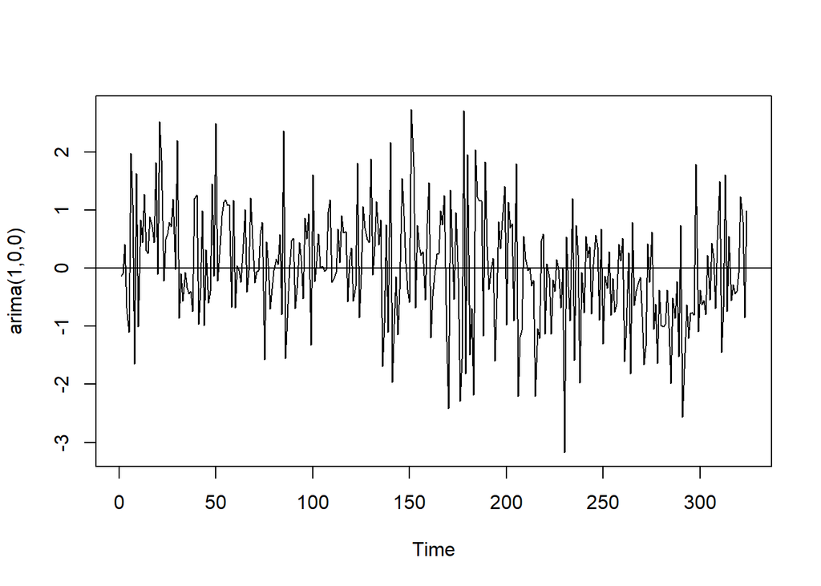

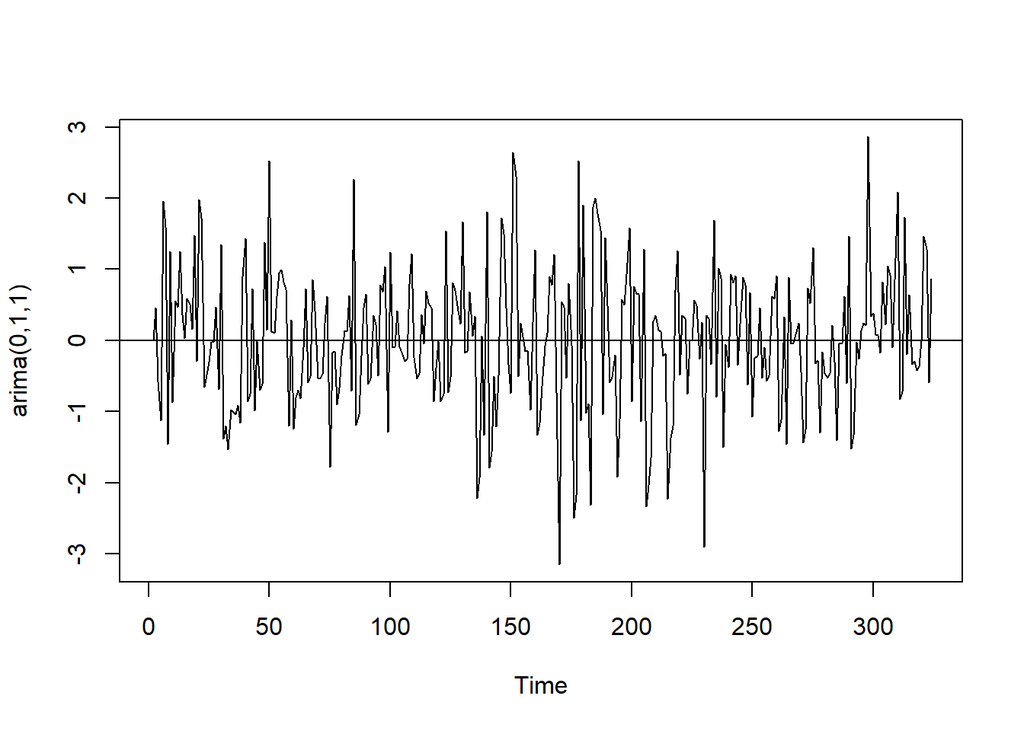

The arima(1,0,0) model has a lag problem with many lags being significant. The arima(0,1,1) model doesn’t have any significant lags except for lag100 and the Ljung-Box test gives a good result of failing to reject the null hypothesis of not showing lack of fit. We will only move forward with the arima(0,1,1) model from this point on.

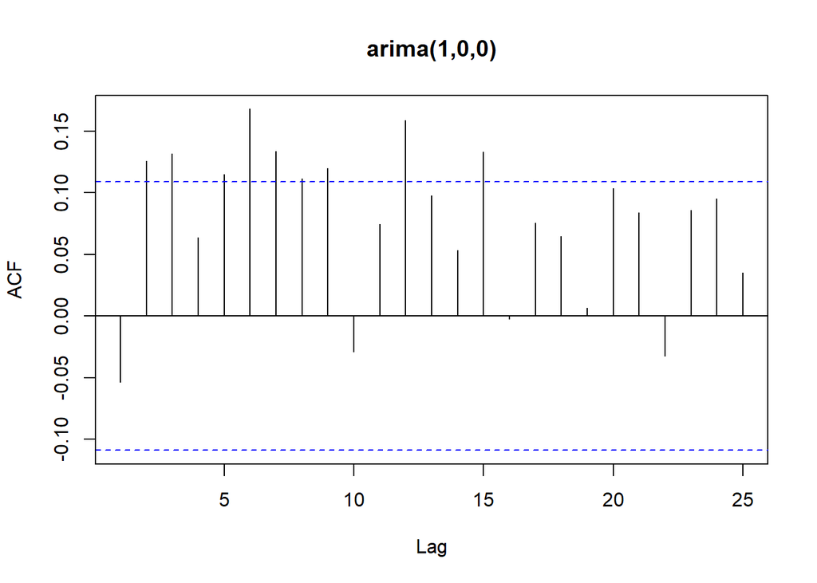

```
##
##  Box-Ljung test
##
## data:  residuals from  model2
## X-squared = 52.512, df = 11, p-value = 2.201e-07
```

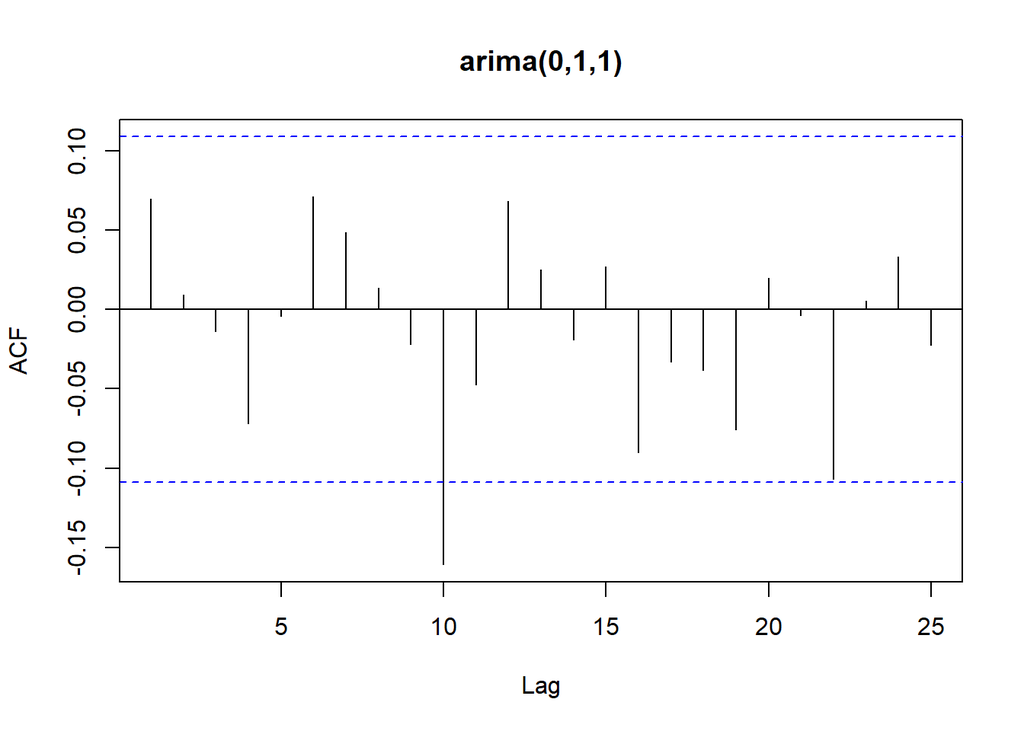

```
##
##  Box-Ljung test
##
## data:  residuals from  model3
## X-squared = 17.081, df = 11, p-value = 0.1055
```

From the following outputs, we can conclude that the arima(0,1,1) model fits well - normality is good, the residuals are also good, and the p-values are acceptable.

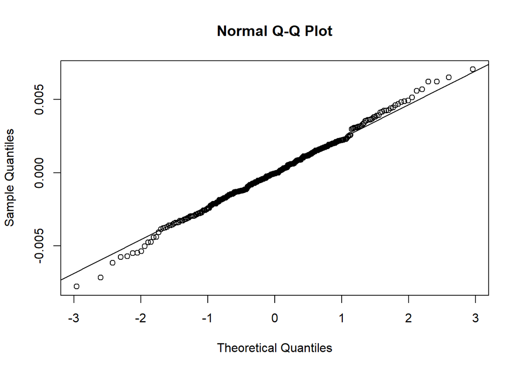

```
##
##  Shapiro-Wilk normality test
##
## data:  residuals(model3)
## W = 0.99689, p-value = 0.791
```

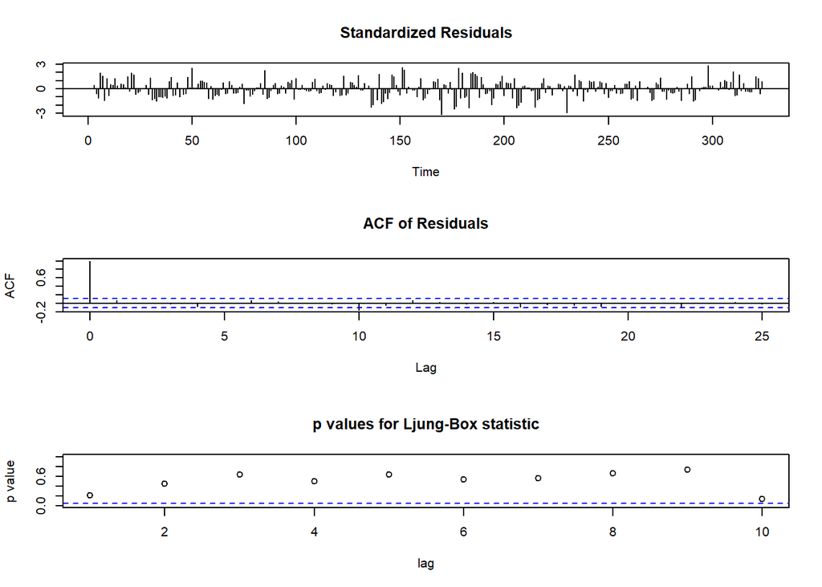

### 9.16

```
##
## Call:
## arima(x = series2, order = c(0, 2, 2))
##
## Coefficients:
##           ma1     ma2
##       -0.9462  0.8548
## s.e.   0.1342  0.2646
##
## sigma^2 estimated as 1.299:  log likelihood = -60.36,  aic = 124.71
```

2. The forcasts are linear when the rest of the plot isn’t.

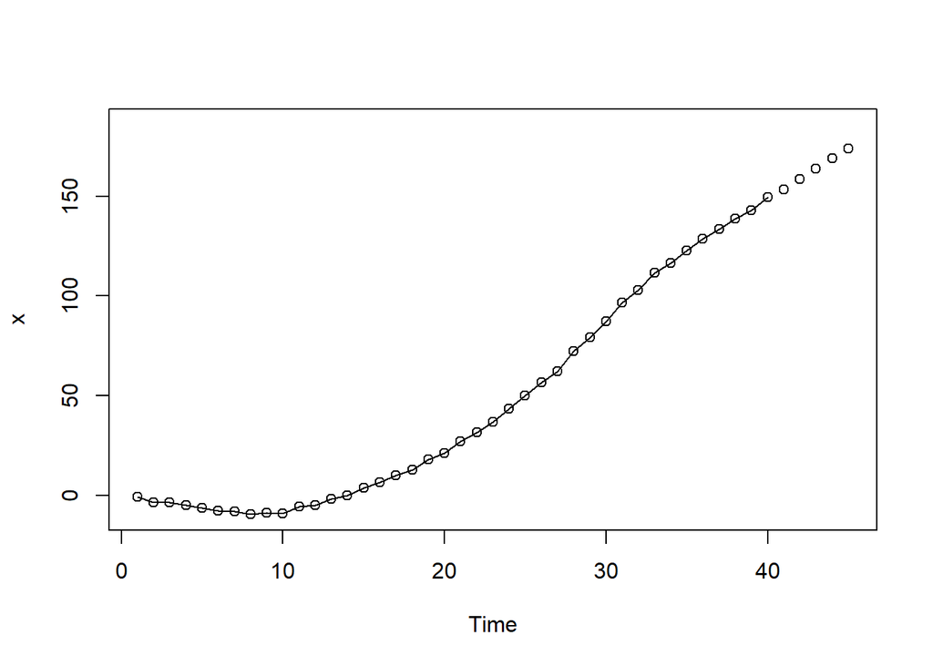

3. The forecast appears to be underestimating the actual values.

```
## Time Series:
## Start = 41
## End = 45
## Frequency = 1
##      actual forecast
## 41 153.6557 153.3885
## 42 161.6516 158.5156
## 43 166.0946 163.6428
## 44 171.9380 168.7699
## 45 179.5304 173.8971
```

4. The actual values fall within the 95% CI except the point at 42 which appears to be on the CI boundary. From the actual values, time 42 is just below the upper CI bound.

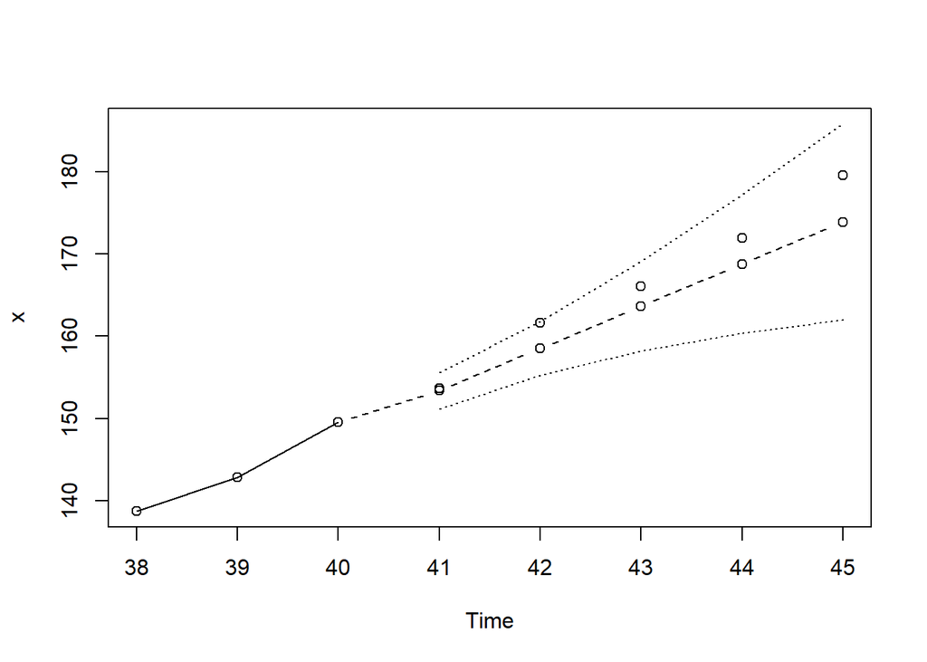

```
## Time Series:
## Start = 41
## End = 45
## Frequency = 1
##       lower   actual    upper
## 41 151.1538 153.6557 155.6232
## 42 155.2688 161.6516 161.7625
## 43 158.1863 166.0946 169.0992
## 44 160.3482 171.9380 177.1917
## 45 161.9705 179.5304 185.8236
```

```
##
## Call:
## arima(x = series3, order = c(0, 2, 2))
##
## Coefficients:
##           ma1     ma2
##       -0.8626  0.7992
## s.e.   0.1249  0.1028
##
## sigma^2 estimated as 0.9572:  log likelihood = -54.24,  aic = 112.47
```

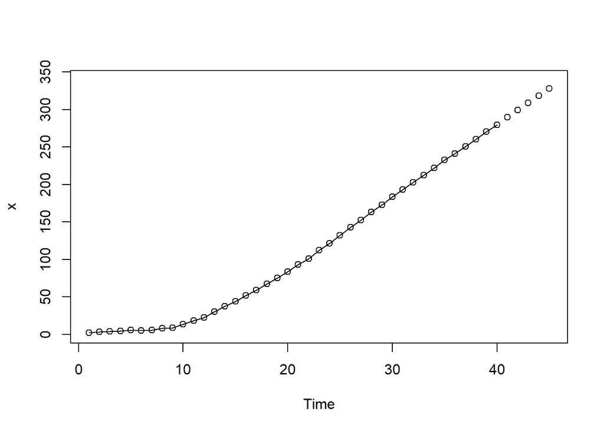

[output not shown]

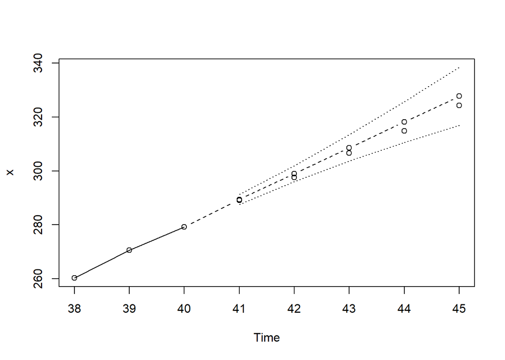

```
## Time Series:
## Start = 41
## End = 45
## Frequency = 1
##      lower2  actual2   upper2
## 41 287.5230 289.1566 291.3583
## 42 296.0985 297.5557 301.9069
## 43 303.6402 306.6612 313.4893
## 44 310.5389 314.7725 325.7148
## 45 316.9714 324.3426 338.4064
```

### 9.23

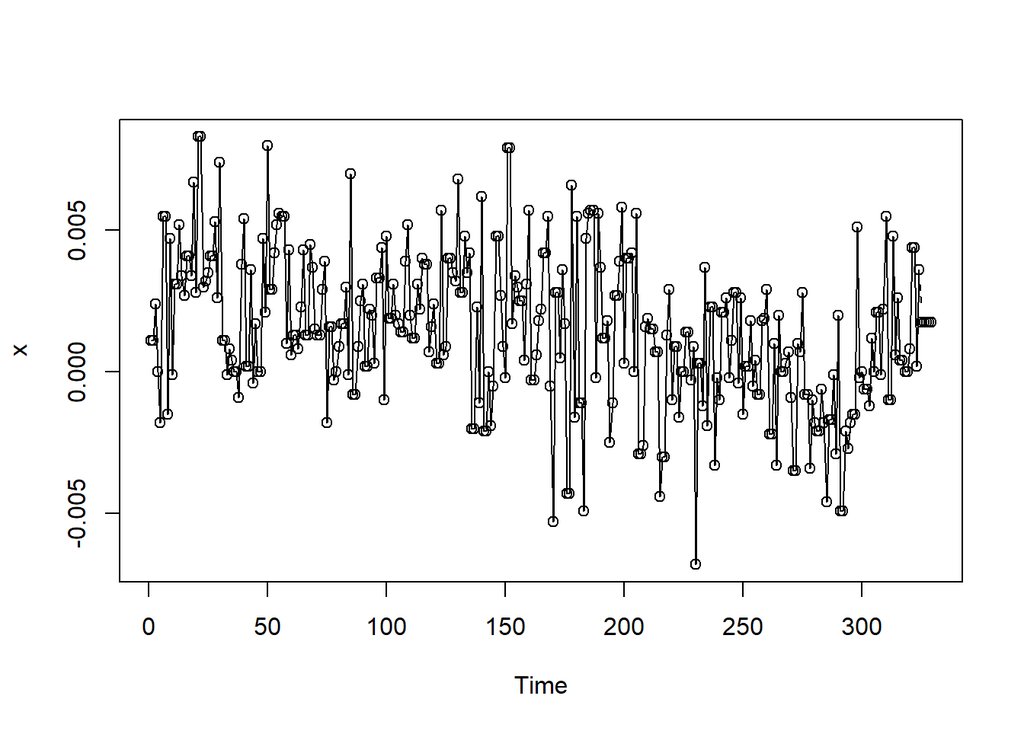

```
## Time Series:
## Start = 325
## End = 329
## Frequency = 1
##            lower   predicted       upper
## 325 -0.003086000 0.001742672 0.006571344
## 326 -0.003125839 0.001742672 0.006611183
## 327 -0.003165355 0.001742672 0.006650699
## 328 -0.003204555 0.001742672 0.006689898
## 329 -0.003243446 0.001742672 0.006728790
```

2. The forcasts are basically constant and the CI is very wide, likely due to the variance seen in previous values.

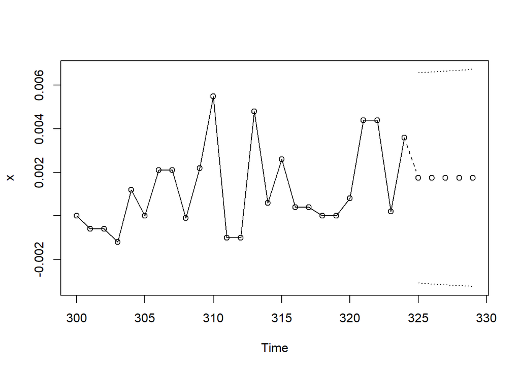

3. Both of these models produce very similar forecasts.

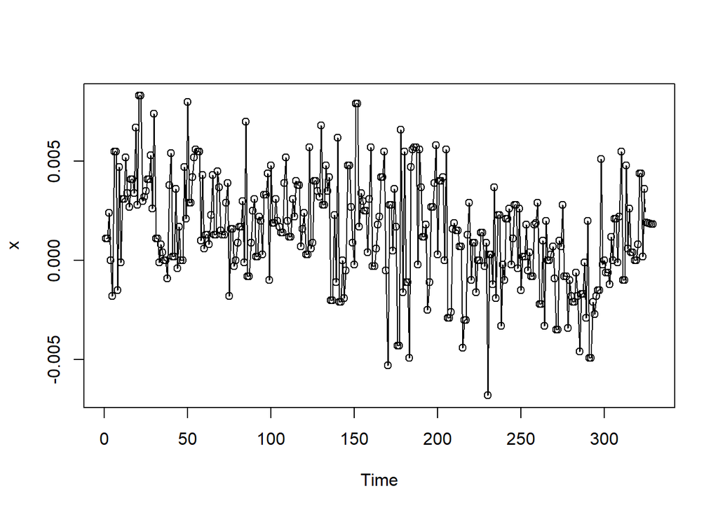

```
## Time Series:
## Start = 325
## End = 329
## Frequency = 1
##            lower   predicted       upper
## 325 -0.002878776 0.001901348 0.006681473
## 326 -0.002947994 0.001879444 0.006706881
## 327 -0.003010803 0.001858695 0.006728193
## 328 -0.003067889 0.001839041 0.006745972
## 329 -0.003119851 0.001820424 0.006760700
```

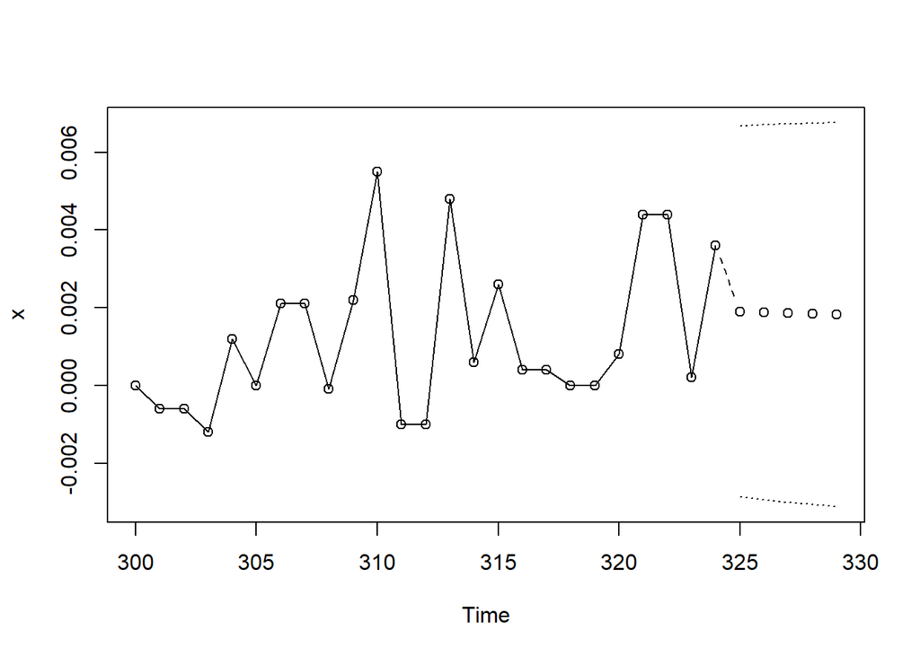